# Practical Machine Learning. Coursera

Juan M. Carrillo

September 3, 2018

# Introduction

Data from personal activity has been collected and the way the activity is done (well or not) is recorded. The objective of the analysis is to predict the class of the activity from its meassurements.

## Load libraries

```r
library (data.table)
library (caret)
```

## Load data

I will load data from the given URL and save into files for future uses.

```r
if (!file.exists("training.csv")) {
    training <- fread ("https://d396qusza40orc.cloudfront.net/predmachlearn/pml-training.csv")
    fwrite (training, "training.csv")
} else {
    training <- fread ("training.csv")
}

if (!file.exists("testing.csv")) {
    testing <- fread ("https://d396qusza40orc.cloudfront.net/predmachlearn/pml-testing.csv")
    fwrite (testing, "testing.csv")
} else {
    testing <- fread ("testing.csv")
}
```

## Split data set

Even if there are already two sets of data (training and test), I will spli the training data set into two sets: training and validation. The latest will be used to measure the performance of the model and fine tunning it if necessary.

```r
set.seed (4833)
InTrain <- createDataPartition (y = training$classe, p = 0.7, list = F)

validation <- training [-InTrain]
training <- training [InTrain]
```

## Optimize data sets

There are some variables with little to no variance, so they add no information to the analysis while adding complexity to it.

```r
nzCol <- nearZeroVar(training)
training <- training [, -nzCol, with = F]

training <- training [, colSums (is.na (training)) == 0, with = F]
training <- training [, -(1:6)]
```

## Training the model

```r
trainC <- trainControl (method = "cv", number = 5)

modelFitRf <- train (classe ~ ., data = training,
                     method = "rf")

modelFitRpart <- train (classe ~ ., data = training,
                      method = "rpart",
                      trControl = trainC)

modelFitKknn <- train (classe ~ ., data = training,
                      method = "knn",
                      trControl = trainC)
```

## Validation of the models

```r
confusionMatrix (factor (validation$classe), predict (modelFitRf, validation))
```

```
## Confusion Matrix and Statistics
##
##           Reference
## Prediction    A    B    C    D    E
##          A 1672    1    1    0    0
##          B    5 1132    2    0    0
##          C    0    3 1016    7    0
##          D    0    0   15  948    1
##          E    0    0    0    0 1082
##
## Overall Statistics
##
##                Accuracy : 0.9941
##                  95% CI : (0.9917, 0.9959)
##     No Information Rate : 0.285
##     P-Value [Acc > NIR] : < 2.2e-16
##
##                   Kappa : 0.9925
##  Mcnemar's Test P-Value : NA
##
## Statistics by Class:
##
##                      Class: A Class: B Class: C Class: D Class: E
## Sensitivity            0.9970   0.9965   0.9826   0.9927   0.9991
## Specificity            0.9995   0.9985   0.9979   0.9968   1.0000
## Pos Pred Value         0.9988   0.9939   0.9903   0.9834   1.0000
## Neg Pred Value         0.9988   0.9992   0.9963   0.9986   0.9998
## Prevalence             0.2850   0.1930   0.1757   0.1623   0.1840
## Detection Rate         0.2841   0.1924   0.1726   0.1611   0.1839
## Detection Prevalence   0.2845   0.1935   0.1743   0.1638   0.1839
## Balanced Accuracy      0.9983   0.9975   0.9903   0.9947   0.9995
```

```r
confusionMatrix (factor (validation$classe), predict (modelFitRpart, validation))
```

```
## Confusion Matrix and Statistics
##
##           Reference
## Prediction    A    B    C    D    E
##          A 1509   29  109    0   27
##          B  466  399  274    0    0
##          C  487   31  508    0    0
##          D  453  148  363    0    0
##          E  132  155  302    0  493
##
## Overall Statistics
##
##                Accuracy : 0.4943
##                  95% CI : (0.4815, 0.5072)
##     No Information Rate : 0.5178
##     P-Value [Acc > NIR] : 0.9998
##
##                   Kappa : 0.3392
##  Mcnemar's Test P-Value : NA
##
## Statistics by Class:
##
##                      Class: A Class: B Class: C Class: D Class: E
## Sensitivity            0.4952   0.5236  0.32648       NA  0.94808
## Specificity            0.9419   0.8556  0.88034   0.8362  0.89021
## Pos Pred Value         0.9014   0.3503  0.49513       NA  0.45564
## Neg Pred Value         0.6348   0.9235  0.78432       NA  0.99438
## Prevalence             0.5178   0.1295  0.26440   0.0000  0.08836
## Detection Rate         0.2564   0.0678  0.08632   0.0000  0.08377
## Detection Prevalence   0.2845   0.1935  0.17434   0.1638  0.18386
## Balanced Accuracy      0.7186   0.6896  0.60341       NA  0.91915
```

```r
confusionMatrix (factor (validation$classe), predict (modelFitKknn, validation))
```

```
## Confusion Matrix and Statistics
##
##           Reference
## Prediction    A    B    C    D    E
##          A 1595   21   20   30    8
##          B   58  983   40   32   26
##          C   13   39  929   23   22
##          D   13    9   56  872   14
##          E   22   47   19   25  969
##
## Overall Statistics
##
##                Accuracy : 0.9088
##                  95% CI : (0.9011, 0.916)
##     No Information Rate : 0.289
##     P-Value [Acc > NIR] : < 2.2e-16
##
##                   Kappa : 0.8845
##  Mcnemar's Test P-Value : 1.016e-10
##
## Statistics by Class:
##
##                      Class: A Class: B Class: C Class: D Class: E
## Sensitivity            0.9377   0.8944   0.8731   0.8880   0.9326
## Specificity            0.9811   0.9674   0.9799   0.9812   0.9767
## Pos Pred Value         0.9528   0.8630   0.9055   0.9046   0.8956
## Neg Pred Value         0.9748   0.9756   0.9722   0.9776   0.9854
## Prevalence             0.2890   0.1867   0.1808   0.1669   0.1766
## Detection Rate         0.2710   0.1670   0.1579   0.1482   0.1647
## Detection Prevalence   0.2845   0.1935   0.1743   0.1638   0.1839
## Balanced Accuracy      0.9594   0.9309   0.9265   0.9346   0.9547
```

## Predictors importance

From the fitted model we can see that the number of predictors used does not increase neccesarily the accuracy of the model.

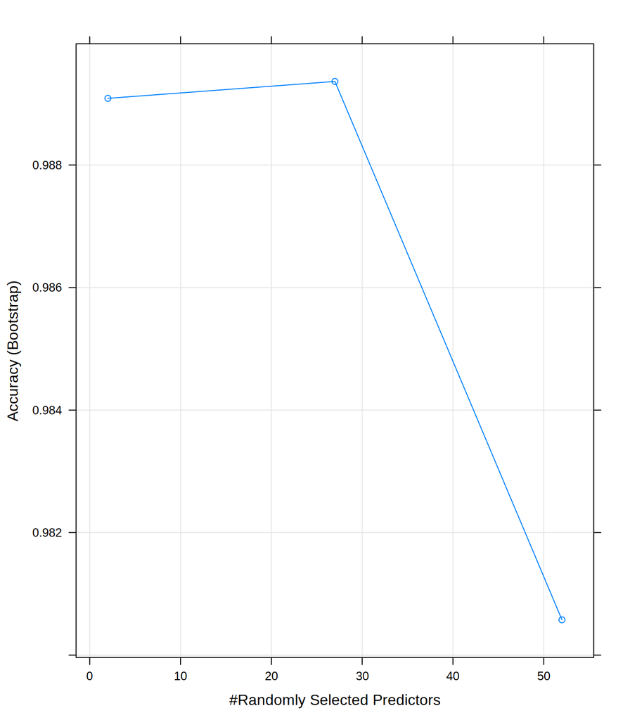

```r
plot (modelFitRf)
```

## Out-of-sample error

The model fitted on the training is expected to be more accurated when tested on the training data itself (in-sample error) than the error applied to the validation (or testing) data set (out-of-sample error).

## Prediction

```r
predict (modelFitKknn, testing)
```

```
##  [1] B A B A A E D B A A B C B A E E A B B B
## Levels: A B C D E
```